# Re-analysis of an Agreement Study

```r
library(SimplyAgree)
library(tidyverse)
data("temps")
df_temps = temps
```

# Re-analysis of a Previous Study of Agreement

In the study by Ravanelli and Jay (2020), they attempted to estimate the effect of varying the time of day (AM or PM) on the measurement of thermoregulatory variables (e.g., rectal and esophageal temperature). In total, participants completed 6 separate trials wherein these variables were measured. While this is a robust study of these variables the analyses focused on ANOVAs and t-tests to determine whether or not the time-of-day (AM or PM). This poses a problem because 1) they were trying to test for equivalence and 2) this is a study of *agreement* not *differences* (See Lin (1989)). Due to the latter point, the use of t-test or ANOVAs (F-tests) is rather inappropriate since they provide an answer to different, albeit related, question.

Instead, the authors could test their hypotheses by using tools that estimate the absolute *agreement* between the AM and PM sessions within each condition. This is rather complicated because we have multiple measurement within each participant. However, between the tools included in `SimplyAgree`[^1] I believe we can get closer to the right answer.

In order to understand the underlying processes of these functions and procedures I highly recommend reading the statistical literature that documents methods within these functions. For the `cccrm` package please see the work by Josep L. Carrasco and Jover (2003), Josep L. Carrasco, King, and Chinchilli (2009), and Josep L. Carrasco et al. (2013). The `loa_lme` function was inspired by the work of Parker et al. (2016) which documented how to implement multi-level models and bootstrapping to estimate the limits of agreement.

# Concordance

An easy approach to measuring agreement between 2 conditions or measurement tools is through the concordance correlation coefficient (CCC). The CCC essentially provides a single coefficient (values between 0 and 1) that provides an estimate to how closely one measurement is to another. It is a type of intraclass correlation coefficient that takes into account the mean difference between two measurements. In other words, if we were to draw a line of identity on a graph and plot two measurements (X & Y), the closer those points are to the line of identity the higher the CCC (and vice versa).

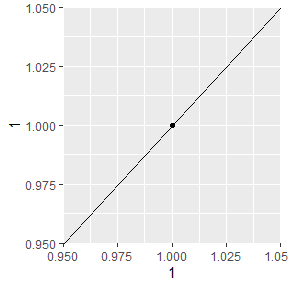

Example of the Line of Identity

```r
qplot(1,1) + geom_abline(intercept = 0, slope = 1)
```

In the following sections, let us see how well esophageal and rectal temperature are in agreement after exercising in the heat for 1 hour at differing conditions.

## Rectal Temperature

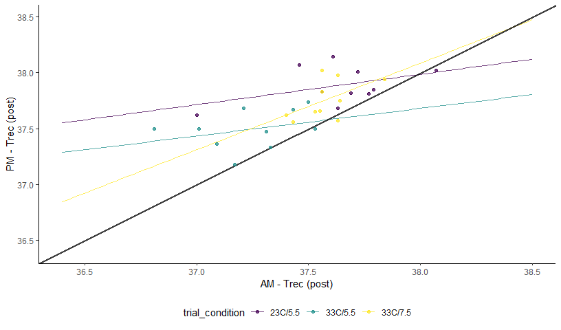

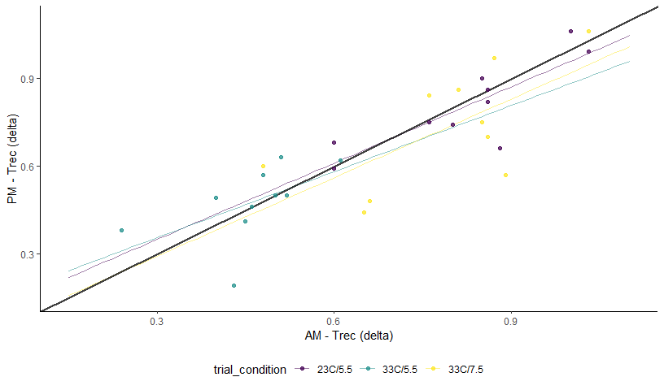

# Esophageal Temperature

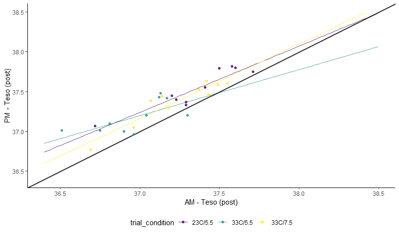

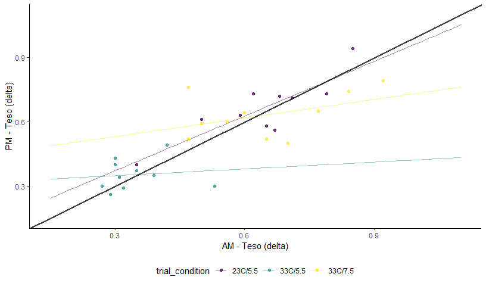

# Limits of Agreement

The `loa_lme` function can be used to calculate the “limits of agreement”. Typically the 95% Limits of Agreement are calculated which provide the difference between two measuring systems for 95% of future measurements pairs. In order to do that we will need the data in a “wide” format where each measurement (in this case AM and PM) are their own column and then we can calculate a column that is the difference score. Once we have the data in this “wide” format, we can then use the `loa_lme` function to calculate the average difference (mean bias) and the variance (which determines the limits of agreement).

## Rectal Temperature

So we will calculate the limits of agreement using the `loa_lme` function. We will need to identify the columns with the right information using the `diff`, `avg`, `condition`, and `id` arguments. We then select the right data set using the `data` argument. Lastly, we specify the specifics of the conditions for how the limits are calculated. For this specific analysis I decided to calculate 95% limits of agreement with 95% confidence intervals, and I will use percentile bootstrap confidence intervals.

```r
rec.post_loa = SimplyAgree::loa_lme(diff = "diff",
                                    condition = "trial_condition",
                                    id = "id",
                                    avg = "Average",
                                    data = df_rec.post,
                                    conf.level = .95,
                                    agree.level = .95,
                                    replicates = 199,
                                    type = "perc")
```

When we create a table of the limits of agreement (LoA), at least for Trec post exercise, are providing the same conclusion (poor agreement).

```r
knitr::kable(rec.post_loa$loa,
             caption = "LoA: Trec Post Exercise")
```

LoA: Trec Post Exercise

| term | condition | estimate | bias | se | lower.ci | upper.ci |
| --- | --- | --- | --- | --- | --- | --- |
| Bias | 23C/5.5 | 0.2550000 | -0.0114061 | 0.0707957 | 0.1058965 | 0.3750531 |
| Bias | 33C/5.5 | 0.2540000 | 0.0044150 | 0.0724833 | 0.1071222 | 0.4044288 |
| Bias | 33C/7.5 | 0.1810000 | -0.0084558 | 0.0708715 | 0.0263866 | 0.3118697 |
| Lower LoA | 23C/5.5 | -0.1708766 | -0.0129563 | 0.0919009 | -0.3746394 | 0.0005661 |
| Lower LoA | 33C/5.5 | -0.1718766 | 0.0028648 | 0.0943708 | -0.3478418 | 0.0107792 |
| Lower LoA | 33C/7.5 | -0.2448766 | -0.0100059 | 0.0875189 | -0.4389267 | -0.0866145 |
| Upper LoA | 23C/5.5 | 0.6808766 | -0.0098559 | 0.0911554 | 0.4887056 | 0.8675360 |
| Upper LoA | 33C/5.5 | 0.6798766 | 0.0059652 | 0.0912843 | 0.5129644 | 0.8784498 |
| Upper LoA | 33C/7.5 | 0.6068766 | -0.0069056 | 0.0954830 | 0.3783011 | 0.7849023 |

Furthermore, we can visualize the results with a typical Bland-Altman plot of the LoA.

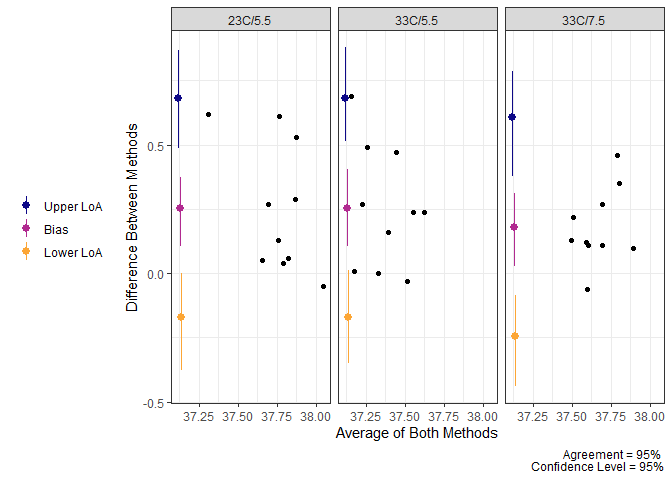

Limits of Agreement for Trec Post Exercise

```r
plot(rec.post_loa)
```

Now, when we look at the Delta values for Trec we find that there is much closer agreement (maybe even acceptable agreement) when we look at LoA. However, we cannot say that the average difference would be less than 0.25 which may not be acceptable for some researchers.

```r
knitr::kable(rec.delta_loa$loa,
             caption = "LoA: Delta Trec")
```

LoA: Delta Trec

| term | condition | estimate | bias | se | lower.ci | upper.ci |
| --- | --- | --- | --- | --- | --- | --- |
| Bias | 23C/5.5 | -0.0190000 | -0.0011451 | 0.0396377 | -0.0949281 | 0.0630221 |
| Bias | 33C/5.5 | 0.0150000 | -0.0014430 | 0.0372452 | -0.0497428 | 0.0910483 |
| Bias | 33C/7.5 | -0.0590000 | 0.0000772 | 0.0391803 | -0.1331558 | 0.0159793 |
| Lower LoA | 23C/5.5 | -0.2532956 | 0.0015001 | 0.0533380 | -0.3570648 | -0.1638991 |
| Lower LoA | 33C/5.5 | -0.2192956 | 0.0012022 | 0.0479123 | -0.3048820 | -0.1172316 |
| Lower LoA | 33C/7.5 | -0.2932956 | 0.0027224 | 0.0534793 | -0.3946780 | -0.1885677 |
| Upper LoA | 23C/5.5 | 0.2152956 | -0.0037903 | 0.0510084 | 0.1028572 | 0.3286267 |
| Upper LoA | 33C/5.5 | 0.2492956 | -0.0040881 | 0.0527573 | 0.1473752 | 0.3507382 |
| Upper LoA | 33C/7.5 | 0.1752956 | -0.0025680 | 0.0501465 | 0.0733961 | 0.2711665 |

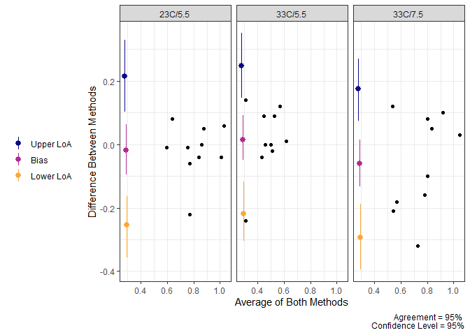

Limits of Agreement for Delta Trec

```r
plot(rec.delta_loa)
```

## Esophageal Temperature

We can repeat the process for esophageal temperature. Overall, the results are fairly similar, and while there is better agreement on the delta (change scores), it is still fairly difficult to determine that there is “good” agreement between the AM and PM measurements.

```r
eso.post_loa = SimplyAgree::loa_mixed(diff = "diff",
                                     condition = "trial_condition",
                                     id = "id",
                                     data = df_eso.post,
                                     conf.level = .95,
                                     agree.level = .95,
                                     replicates = 199,
                                     type = "bca")
```

```r
knitr::kable(eso.post_loa$loa,
             caption = "LoA: Teso Post Exercise")
```

LoA: Teso Post Exercise

| term | condition | estimate | bias | se | lower.ci | upper.ci |
| --- | --- | --- | --- | --- | --- | --- |
| Bias | 23C/5.5 | 0.180000 | 0.0054383 | 0.0414297 | 0.1018153 | 0.2727195 |
| Bias | 33C/5.5 | 0.212000 | 0.0003411 | 0.0409850 | 0.1225349 | 0.2781630 |
| Bias | 33C/7.5 | 0.146000 | 0.0067433 | 0.0411734 | 0.0699717 | 0.2437454 |
| Lower LoA | 23C/5.5 | -0.078867 | 0.0087499 | 0.0577083 | -0.1882852 | 0.0362440 |
| Lower LoA | 33C/5.5 | -0.046867 | 0.0036528 | 0.0562961 | -0.1450997 | 0.0710961 |
| Lower LoA | 33C/7.5 | -0.112867 | 0.0100549 | 0.0533235 | -0.2205322 | 0.0096297 |
| Upper LoA | 23C/5.5 | 0.438867 | 0.0021267 | 0.0519004 | 0.3284062 | 0.5399114 |
| Upper LoA | 33C/5.5 | 0.470867 | -0.0029705 | 0.0527384 | 0.3570791 | 0.5748910 |
| Upper LoA | 33C/7.5 | 0.404867 | 0.0034317 | 0.0560191 | 0.3054799 | 0.5188644 |

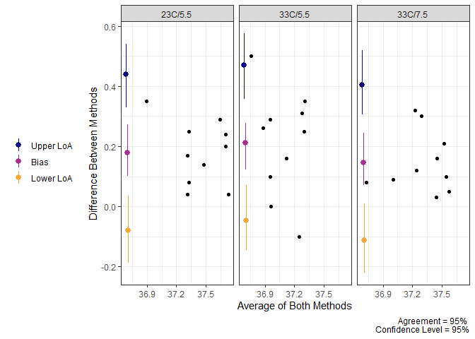

Limits of Agreement for Teso Post Exercise

```r
plot(eso.post_loa)
```

```r
knitr::kable(eso.delta_loa$loa,
             caption = "LoA: Delta Teso")
```

LoA: Delta Teso

| term | condition | estimate | bias | se | lower.ci | upper.ci |
| --- | --- | --- | --- | --- | --- | --- |
| Bias | 23C/5.5 | 0.0200000 | -0.0032266 | 0.0346942 | -0.0528344 | 0.0930582 |
| Bias | 33C/5.5 | 0.0050000 | -0.0009160 | 0.0346594 | -0.0687195 | 0.0839039 |
| Bias | 33C/7.5 | -0.0170000 | -0.0026115 | 0.0345165 | -0.0870805 | 0.0516728 |
| Lower LoA | 23C/5.5 | -0.1992475 | -0.0007217 | 0.0467556 | -0.2940191 | -0.1094022 |
| Lower LoA | 33C/5.5 | -0.2142475 | 0.0015889 | 0.0452052 | -0.2997399 | -0.1297578 |
| Lower LoA | 33C/7.5 | -0.2362475 | -0.0001066 | 0.0480083 | -0.3370631 | -0.1477120 |
| Upper LoA | 23C/5.5 | 0.2392475 | -0.0057314 | 0.0474541 | 0.1312817 | 0.3429716 |
| Upper LoA | 33C/5.5 | 0.2242475 | -0.0034208 | 0.0488839 | 0.1350650 | 0.3297975 |
| Upper LoA | 33C/7.5 | 0.2022475 | -0.0051163 | 0.0459192 | 0.1140479 | 0.2865703 |

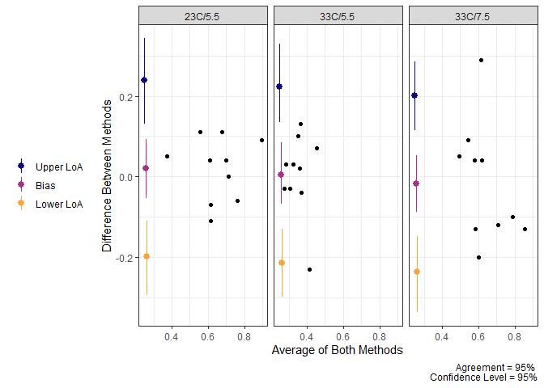

Limits of Agreement for Delta Teso

```r
plot(eso.delta_loa)
```

# References

Carrasco, Josep L., and Lluı́s Jover. 2003. “Estimating the Generalized Concordance Correlation Coefficient Through Variance Components.” *Biometrics* 59 (4): 849–58. https://doi.org/10.1111/j.0006-341x.2003.00099.x.

Carrasco, Josep L., Tonya S. King, and Vernon M. Chinchilli. 2009. “The Concordance Correlation Coefficient for Repeated Measures Estimated by Variance Components.” *Journal of Biopharmaceutical Statistics* 19 (1): 90–105. https://doi.org/10.1080/10543400802527890.

Carrasco, Josep Lluis, and Josep Puig Martinez. 2020. *Cccrm: Concordance Correlation Coefficient for Repeated (and Non-Repeated) Measures*. https://CRAN.R-project.org/package=cccrm.

Carrasco, Josep L., Brenda R. Phillips, Josep Puig-Martinez, Tonya S. King, and Vernon M. Chinchilli. 2013. “Estimation of the Concordance Correlation Coefficient for Repeated Measures Using SAS and r.” *Computer Methods and Programs in Biomedicine* 109 (3): 293–304. https://doi.org/10.1016/j.cmpb.2012.09.002.

Lin, Lawrence I-Kuei. 1989. “A Concordance Correlation Coefficient to Evaluate Reproducibility.” *Biometrics* 45 (1): 255. https://doi.org/10.2307/2532051.

Parker, Richard A., Christopher J. Weir, Noah Rubio, Roberto Rabinovich, Hilary Pinnock, Janet Hanley, Lucy McCloughan, et al. 2016. “Application of Mixed Effects Limits of Agreement in the Presence of Multiple Sources of Variability: Exemplar from the Comparison of Several Devices to Measure Respiratory Rate in COPD Patients.” Edited by Hong-Long (James) Ji. *PLOS ONE* 11 (12): e0168321. https://doi.org/10.1371/journal.pone.0168321.

Ravanelli, Nicholas, and Ollie Jay. 2020. “The Change in Core Temperature and Sweating Response During Exercise Are Unaffected by Time of Day Within the Wake Period.” *Medicine and Science in Sports and Exercise*. https://doi.org/10.1249/mss.0000000000002575.

[^1]: Josep Lluis Carrasco and Martinez (2020) is another package to check out